# Project of Data Science Course

ZZG

7/28/2017

## Part1: Exploratory Data Analysis

```r
# Read data in and check the summary
library(caret);library(tidyverse)
setwd("~/Downloads/Coursera/Practical Machine Learning_John Hopkings")
training <- read.csv("pml-training.csv")[-1]
testing <- read.csv("pml-testing.csv")[-1]
#summary(training)

# In summary we can see lots of predictors are basicly blank or invalid
# So the feature size is reduced to contain more valid information
# In future we can compare the training performance between the full data and reduced data
trainingReduced <- training[,c(1:10,36:48,59:67,83:85,101,112:123,139,150:159)]
summary(trainingReduced)
```

```
##     user_name    raw_timestamp_part_1 raw_timestamp_part_2
##  adelmo  :3892   Min.   :1.322e+09    Min.   :   294
##  carlitos:3112   1st Qu.:1.323e+09    1st Qu.:252912
##  charles :3536   Median :1.323e+09    Median :496380
##  eurico  :3070   Mean   :1.323e+09    Mean   :500656
##  jeremy  :3402   3rd Qu.:1.323e+09    3rd Qu.:751891
##  pedro   :2610   Max.   :1.323e+09    Max.   :998801
##
##           cvtd_timestamp  new_window    num_window      roll_belt
##  28/11/2011 14:14: 1498   no :19216   Min.   :  1.0   Min.   :-28.90
##  05/12/2011 11:24: 1497   yes:  406   1st Qu.:222.0   1st Qu.:  1.10
##  30/11/2011 17:11: 1440               Median :424.0   Median :113.00
##  05/12/2011 11:25: 1425               Mean   :430.6   Mean   : 64.41
##  02/12/2011 14:57: 1380               3rd Qu.:644.0   3rd Qu.:123.00
##  02/12/2011 13:34: 1375               Max.   :864.0   Max.   :162.00
##  (Other)         :11007
##    pitch_belt          yaw_belt       total_accel_belt  gyros_belt_x
##  Min.   :-55.8000   Min.   :-180.00   Min.   : 0.00    Min.   :-1.040000
##  1st Qu.:  1.7600   1st Qu.: -88.30   1st Qu.: 3.00    1st Qu.:-0.030000
##  Median :  5.2800   Median : -13.00   Median :17.00    Median : 0.030000
##  Mean   :  0.3053   Mean   : -11.21   Mean   :11.31    Mean   :-0.005592
##  3rd Qu.: 14.9000   3rd Qu.:  12.90   3rd Qu.:18.00    3rd Qu.: 0.110000
##  Max.   : 60.3000   Max.   : 179.00   Max.   :29.00    Max.   : 2.220000
##
##   gyros_belt_y       gyros_belt_z      accel_belt_x       accel_belt_y
##  Min.   :-0.64000   Min.   :-1.4600   Min.   :-120.000   Min.   :-69.00
##  1st Qu.: 0.00000   1st Qu.:-0.2000   1st Qu.: -21.000   1st Qu.:  3.00
##  Median : 0.02000   Median :-0.1000   Median : -15.000   Median : 35.00
##  Mean   : 0.03959   Mean   :-0.1305   Mean   :  -5.595   Mean   : 30.15
##  3rd Qu.: 0.11000   3rd Qu.:-0.0200   3rd Qu.:  -5.000   3rd Qu.: 61.00
##  Max.   : 0.64000   Max.   : 1.6200   Max.   :  85.000   Max.   :164.00
##
##   accel_belt_z     magnet_belt_x   magnet_belt_y   magnet_belt_z
##  Min.   :-275.00   Min.   :-52.0   Min.   :354.0   Min.   :-623.0
##  1st Qu.:-162.00   1st Qu.:  9.0   1st Qu.:581.0   1st Qu.:-375.0
##  Median :-152.00   Median : 35.0   Median :601.0   Median :-320.0
##  Mean   : -72.59   Mean   : 55.6   Mean   :593.7   Mean   :-345.5
##  3rd Qu.:  27.00   3rd Qu.: 59.0   3rd Qu.:610.0   3rd Qu.:-306.0
##  Max.   : 105.00   Max.   :485.0   Max.   :673.0   Max.   : 293.0
##
```

[output cut: 73 more lines]

```
##  Min.   :-446.00   Min.   :-1280.0   Min.   :-896.0   Min.   :-973.0
##  1st Qu.:-182.00   1st Qu.: -616.0   1st Qu.:   2.0   1st Qu.: 191.0
##  Median : -39.00   Median : -378.0   Median : 591.0   Median : 511.0
##  Mean   : -55.29   Mean   : -312.6   Mean   : 380.1   Mean   : 393.6
##  3rd Qu.:  26.00   3rd Qu.:  -73.0   3rd Qu.: 737.0   3rd Qu.: 653.0
##  Max.   : 291.00   Max.   :  672.0   Max.   :1480.0   Max.   :1090.0
##
##  classe
##  A:5580
##  B:3797
##  C:3422
##  D:3216
##  E:3607
##
##
```

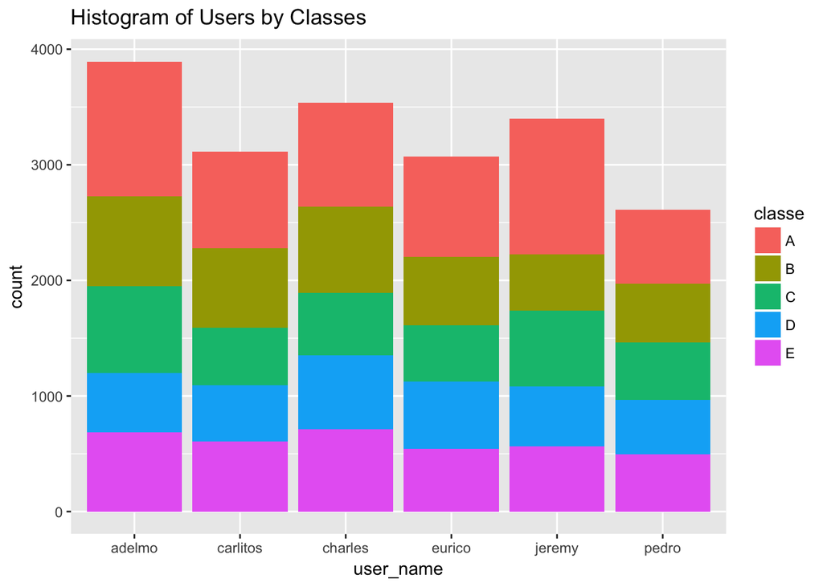

```r
# I noticed the variable "new_window" has largely imbalanced data, so delete
trainingReduced <- trainingReduced[,-5]

testingReduced <- testing[,which(names(testing) %in% names(trainingReduced))]

# Plot the user distribution and show their exercise manner
qplot(user_name,data=trainingReduced,fill=classe,main = "Histogram of Users by Classes")
```

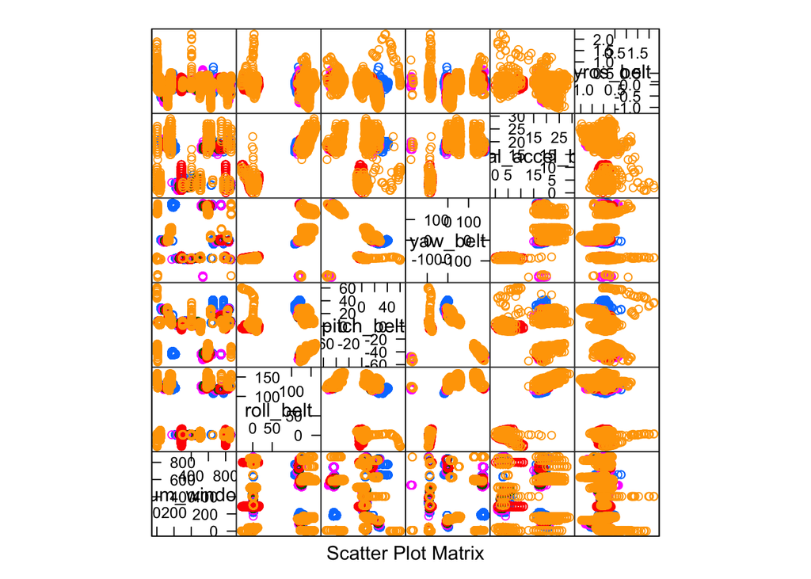

```r
# Use featurePlot() to see the relations between several pairs of variables
# We can see some correlation between certain pairs
# However we do not want to remove any variable carelessly
featurePlot(trainingReduced[,5:10],trainingReduced$classe,"pairs")
```

```r
#featurePlot(trainingReduced[,25:35],trainingReduced$classe,"pairs")
```

Comments:  
1) Fitting models are more complicated than it looks. We should pre-process variables on missing values, scales and other problems.  
2) If certain predictor has too many missing values, it won’t contribute to our model, that’s why I deleted quite a few variables here to make the dataset more efficient.  
3) Try various way to explore the data is also crucial. It will help us to choose certain variables, deal with correlation if there’s any, and explain our final model with more sense.

## Part2: Model Fitting

```r
set.seed(0818)
inTrain <- createDataPartition(y=trainingReduced$classe,p=0.7,list=F)
train <- trainingReduced[inTrain,]
test <- trainingReduced[-inTrain,]

# First I want to try tree model to this classification problem
# The result is not satisfying, maybe because our data is not highly categorical
modTree <- train(classe ~.,data=train, method='rpart')
treePredTest <- predict(modTree,test)
table(treePredTest,test$classe)
```

```
##
## treePredTest    A    B    C    D    E
##            A 1100  102    3    0    0
##            B  275  455  162  347   90
##            C  297  582  861  617  494
##            D    0    0    0    0    0
##            E    2    0    0    0  498
```

```r
errRateTree <- sum(treePredTest != test$classe)/nrow(test)
errRateTree
```

```
## [1] 0.5048428
```

```r
# Then we can try LDA model to classify
modLda <- train(classe ~.,data=train, method='lda')
ldaPredTest <- predict(modLda,test)
table(ldaPredTest,test$classe)
```

```
##
## ldaPredTest    A    B    C    D    E
##           A 1511  127    1    0    0
##           B  147  836  120    0    0
##           C   16  172  872   99    4
##           D    0    4   32  813  107
##           E    0    0    1   52  971
```

```r
errRateLda <- sum(ldaPredTest != test$classe)/nrow(test)
errRateLda
```

```
## [1] 0.1498726
```

```r
# Remember we haven't seen clear correlation between variables
# So we can try naive bayes model to classify
# From the result, seems the independence assumption may not hold perfectly
# Compare to LDA, the model is not doing as well
modNb <- train(classe ~.,data=train, method='naive_bayes')
nbPredTest <- predict(modNb,test)
table(nbPredTest,test$classe)
```

```
##
## nbPredTest    A    B    C    D    E
##          A 1662  363  350  411  132
##          B    7  661   40    2   74
##          C    5  111  636   74   31
##          D    0    4    0  450   37
##          E    0    0    0   27  808
```

```r
errRateNb <- sum(nbPredTest != test$classe)/nrow(test)
errRateNb
```

```
## [1] 0.2834325
```

```r
# Now I will try KNN method
# I use class package to run the algorithm
# Using KNN method needs several pre-processing
# I change important factor variables into dummy variables
# Also I center and scale predictors
library(class)
userTrain <- matrix(0,nrow=nrow(train),ncol=6)
colnames(userTrain) <- unique(train$user_name)
for (row in 1:nrow(train)){
  userTrain[row,which(train$user_name[row] == colnames(userTrain))] <- 1
}
userTrain <- userTrain[,-6]

userTest <- matrix(0,nrow=nrow(test),ncol=5)
colnames(userTest) <- colnames(userTrain)
for (row in 1:nrow(test)){
  userTest[row,which(test$user_name[row] == colnames(userTest))] <- 1
}

#knnPred <- knn(train[,-c(1,4,58)],test[,-c(1,4,58)],train[,58],k=15)
#table(modKnn,test$classe)
#errRateKnn <- sum(modKnn != test$classe)/nrow(test)
#errRateKnn

trainPreProcess <- scale(cbind(userTrain,train[-c(1,4,58)]), center = TRUE, scale = TRUE)
testPreProcess <- scale(cbind(userTest,test[,-c(1,4,58)]), center = TRUE, scale = TRUE)

knnPredScale <- knn(trainPreProcess,testPreProcess,train[,58],k=25)
errRateKnn <- sum(knnPredScale != test$classe)/nrow(test)
errRateKnn
```

```
## [1] 0.1112999
```

```r
# Lastly we can try SVM model to classify
# We use all the predictors in our data
library(e1071)
modSvm <- svm(classe ~.,data=train[,-4])
svmPredTest <- predict(modSvm,test)
table(svmPredTest,test$classe)
```

```
##
## svmPredTest    A    B    C    D    E
##           A 1649   66    2    5    0
##           B    9 1038   41    0    5
##           C   16   30  969   77   19
##           D    0    4   13  881   23
##           E    0    1    1    1 1035
```

```r
errRateSvm <- sum(svmPredTest != test$classe)/nrow(test)
errRateSvm
```

```
## [1] 0.05318607
```

```r
errRates <- data.frame("Tree"=errRateTree,"LDA"=errRateLda,"NaiveBayes"=errRateNb,"KNN"=errRateKnn,"SVM"=errRateSvm)
errRates
```

```
##        Tree       LDA NaiveBayes       KNN        SVM
## 1 0.5048428 0.1498726  0.2834325 0.1112999 0.05318607
```

Comments:  
1) Here I choose 5 models to train my data: Tree, LDA, Naive Bayes, KNN, and SVM.  
2) For certain model, such as KNN, we should pre-process the data by ourselves due to the design of the package(pacakge “class”). If we don’t scale and center the training data, and the testing data, the error rate will be extremely high, which is almost like random guess.  
3) From all 5 models, we can see SVM performs the best, and Tree performs the worst. Go back to my data, most of the variables are numerical, while Tree model is more efficient on categorical variables.  
4) Here I didn’t use any cross-validation besides the default settings, I will use different parameter settings in next part to compare the results.

## Part3: Cross Validation

```r
# Tree model trained with CV
treeTrainControl<- trainControl(method="LGOCV", repeats=5, p=0.7)
modTreeCv <- train(classe ~.,data=train, method='rpart',trControl = treeTrainControl)
table(predict(modTreeCv,test),test$classe)
```

```
##
##        A    B    C    D    E
##   A 1100  102    3    0    0
##   B  275  455  162  347   90
##   C  297  582  861  617  494
##   D    0    0    0    0    0
##   E    2    0    0    0  498
```

```r
errRateTreeCv <- sum(predict(modTreeCv,test) != test$classe)/nrow(test)
errRateTreeCv
```

```
## [1] 0.5048428
```

```r
# Then we try LDA with different cross validation methods
ldaTrainControl<- trainControl(method="cv", number=25, p=0.8)
modLdaCv <- train(classe ~.,data=train, method='lda',trControl = ldaTrainControl)
table(predict(modLdaCv,test),test$classe)
```

```
##
##        A    B    C    D    E
##   A 1511  127    1    0    0
##   B  147  836  120    0    0
##   C   16  172  872   99    4
##   D    0    4   32  813  107
##   E    0    0    1   52  971
```

```r
errRateLdaCv <- sum(predict(modLdaCv,test) != test$classe)/nrow(test)
errRateLdaCv
```

```
## [1] 0.1498726
```

```r
# Then we change the cross validation methods for Naive Bayes
nbTrainControl<- trainControl(method="boot", number=25, p=0.8)
modNbCv <- train(classe ~.,data=train, method='naive_bayes',trControl = nbTrainControl)
table(predict(modNbCv,test),test$classe)
```

```
##
##        A    B    C    D    E
##   A 1662  363  350  411  132
##   B    7  661   40    2   74
##   C    5  111  636   74   31
##   D    0    4    0  450   37
##   E    0    0    0   27  808
```

```r
errRateNbCv <- sum(predict(modNbCv,test) != test$classe)/nrow(test)
errRateNbCv
```

```
## [1] 0.2834325
```

```r
# Then we use LOOCV cross validation methods for KNN
knnPredScaleCv <- knn.cv(trainPreProcess,train[,58],k=25)
errRateKnnCv <- sum(knnPredScaleCv != train$classe)/nrow(train)
errRateKnnCv
```

```
## [1] 0.1290675
```

```r
# Lastly we can tune SVM model
tune <- tune.control(sampling = 'cross',cross=10)
modSvmCv <- tune.svm(classe ~.,data=train[,-4], tunecontrol = tune)
table(predict(modSvmCv$best.model,test),test$classe)
```

```
##
##        A    B    C    D    E
##   A 1649   66    2    5    0
##   B    9 1038   41    0    5
##   C   16   30  969   77   19
##   D    0    4   13  881   23
##   E    0    1    1    1 1035
```

```r
errRateSvmCv <- sum(predict(modSvmCv$best.model,test) != test$classe)/nrow(test)
errRateSvmCv
```

```
## [1] 0.05318607
```

```r
# Now we bag all the methods to predict
vote <- function(input){
  input <- as.data.frame(table(input))
  inputSorted <- arrange(input,desc(Freq))
  return(inputSorted[1,1])
}

resultTest <- data.frame("TreeResults"=treePredTest,"LdaResults"=ldaPredTest,"NaiveBayesResults"=nbPredTest,"KnnResults"=knnPredScale,"SvmResults"=svmPredTest)

predResultTest <- apply(resultTest,1,vote)
sum(predResultTest == test$classe)/length(predResultTest)
```

```
## [1] 0.9140187
```

```r
# Consolidate all error rates
data.frame("Before CV"=c(errRateTree,errRateLda,errRateNb,errRateKnn,errRateSvm),"After CV"=c(errRateTreeCv,errRateLdaCv,errRateNbCv,errRateKnnCv,errRateSvmCv))
```

```
##    Before.CV   After.CV
## 1 0.50484282 0.50484282
## 2 0.14987256 0.14987256
## 3 0.28343246 0.28343246
## 4 0.11129992 0.12906748
## 5 0.05318607 0.05318607
```

Comment:  
1) In Part2 and this Part, I both splitted the origianl training file into training data and testing data to test the predicting power.  
2) As we say, different cross validation methods have no effects on most of my cases. KNN method show minor difference between the original algorithm and tuned algorithm, however, we can see the default tuning methods built in R packages are already doing a reasonable job.  
3) In addition, in this part I also use the bagged algorithm to consolidate all methods, and to see whether the accuracy would beat the best one of them. However, since our models varied a lot on their performances, the combined accuracy still cannot top SVM, which has around 95% accuracy.

## Part4: Predict on testing dataset

```r
# Predict on the 20 testing data
treePred <- predict(modTree,newdata = testingReduced)
treePred
```

```
##  [1] B A C A C C C C A A C C C A C C C B B C
## Levels: A B C D E
```

```r
ldaPred <- predict(modLda,newdata = testingReduced)
ldaPred
```

```
##  [1] B B B A A E D C A A B C B A E E A B B B
## Levels: A B C D E
```

```r
nbPred <- predict(modNb,newdata = testingReduced)
nbPred
```

```
##  [1] A A A A A A A A A A A A B A E A A B A B
## Levels: A B C D E
```

```r
knnTestPreProcess <- scale(testingReduced[,-c(1,4)], center = TRUE, scale = TRUE)
knnPred <- knn(trainPreProcess[,-c(1:5)],knnTestPreProcess,train[,58],k=25)
knnPred
```

```
##  [1] A A A A A C D D A A D C B A E E A B B B
## Levels: A B C D E
```

```r
svmPred <- predict(modSvm,newdata = testingReduced[,-4])
svmPred
```

```
##  1  2  3  4  5  6  7  8  9 10 11 12 13 14 15 16 17 18 19 20
##  B  A  A  A  A  E  D  B  A  A  B  C  B  A  E  E  A  B  B  B
## Levels: A B C D E
```

```r
# Consolidate the results
predResult <- data.frame("Tree"=treePred,"LDA"=ldaPred,"Naive Bayes"=nbPred,"KNN"=knnPred,"SVM"=svmPred)

# Calculate the vote
voteResult <- apply(predResult,1,vote)
voteResult
```

```
##  1  2  3  4  5  6  7  8  9 10 11 12 13 14 15 16 17 18 19 20
##  B  A  A  A  A  C  D  C  A  A  B  C  B  A  E  E  A  B  B  B
## Levels: A B C E D
```

```r
table(voteResult,svmPred)
```

```
##           svmPred
## voteResult A B C D E
##          A 8 0 0 0 0
##          B 0 6 0 0 0
##          C 0 1 1 0 1
##          E 0 0 0 0 2
##          D 0 0 0 1 0
```

```r
sum(voteResult == svmPred)/length(voteResult)
```

```
## [1] 0.9
```

```r
sum(voteResult == ldaPred)/length(voteResult)
```

```
## [1] 0.85
```

Comments:  
Here we use all 5 models and bagged them to vote, and we get the final classification, which is quite similar to SVM model.